# Course Project 1

Josh

10/18/2020

## Loading and preprocessing the data

The first step in loading the data:

```r
cls = c("integer", "character", "integer")
activity <- read.csv("activity.csv", head=TRUE, colClasses = cls, na.strings = "NA")
head(activity)
```

```
##   steps       date interval
## 1    NA 2012-10-01        0
## 2    NA 2012-10-01        5
## 3    NA 2012-10-01       10
## 4    NA 2012-10-01       15
## 5    NA 2012-10-01       20
## 6    NA 2012-10-01       25
```

Next I will be changing up the data for later analysis:

```r
activity$date <- as.Date(activity$date)
activity_na <- subset(activity, !is.na(activity$steps))
```

## What is mean total number of steps taken per day?

Here I will be showing a histogram of the daily total number of steps taken:

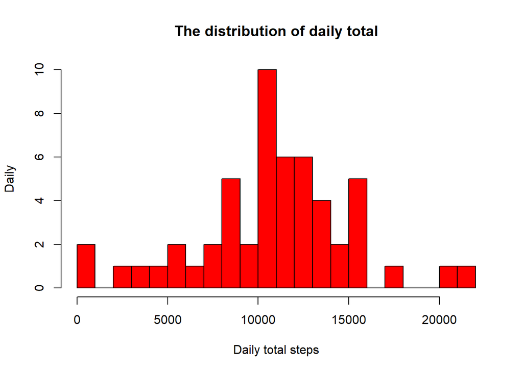

```r
dailysum <- tapply(activity_na$steps, activity_na$date, sum, na.rm=TRUE, simplify=T)
dailysum <- dailysum[!is.na(dailysum)]

hist(x=dailysum,
     col="red",
     breaks=20,
     xlab="Daily total steps",
     ylab="Daily",
     main="The distribution of daily total")
```

Next, I will find the mean and median:

```r
mean(dailysum)
```

```
## [1] 10766.19
```

```r
median(dailysum)
```

```
## [1] 10765
```

## What is the average daily activity pattern?

To find this, we create a time series plot (i.e. type = “l”) of the 5-minute interval and the average number of steps taken, averaged across all days:

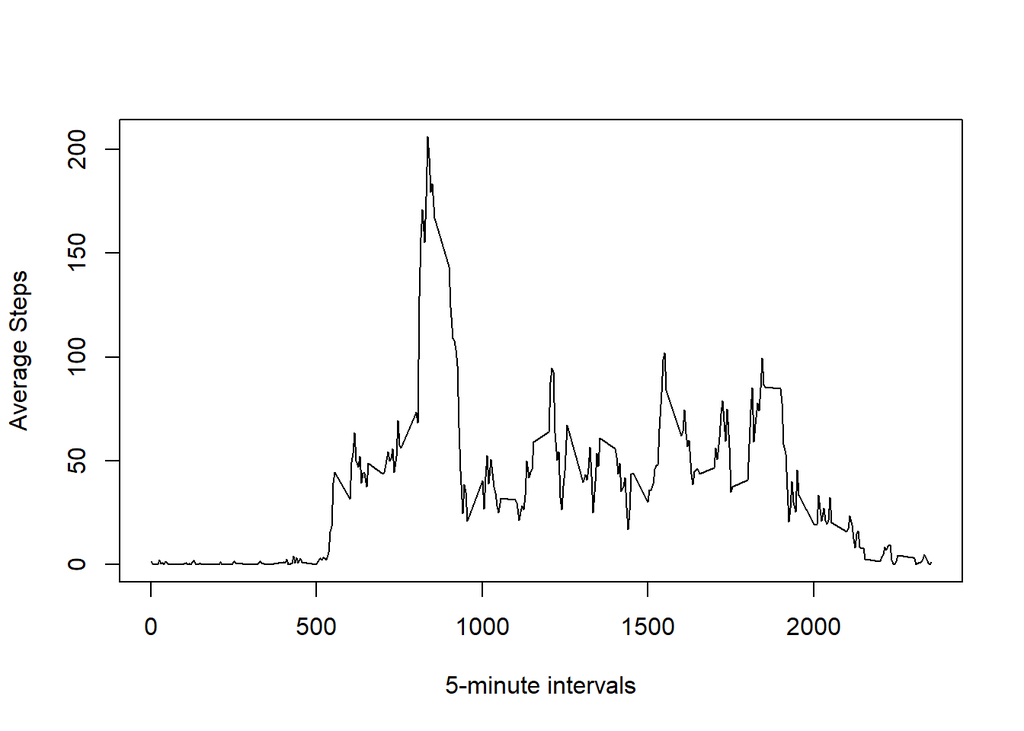

```r
average_integer <- tapply(activity_na$steps, activity_na$interval, mean,
                          na.rm=TRUE, simplify=T)
activity_integer_average <- data.frame(interval=as.integer(names(average_integer)),
                                       avg=average_integer)

with(activity_integer_average,
     plot(interval,
                 avg,
                 type="l",
                 xlab="5-minute intervals",
                 ylab="Average Steps"))
```

Which of these contains the max number of steps?

```r
max_steps <- max(activity_integer_average$avg)
activity_integer_average[activity_integer_average$avg == max_steps, ]
```

```
##     interval      avg
## 835      835 206.1698
```